# Czynniki wpływające na czas rozwiązywania zadań z matematyki PISA 2015 - etap 2

Michał Ciach, Ola Paluszyńska

16 kwietnia 2017

```r
library(ggplot2)
library(moments) # obliczanie kurtozy i skośności rozkładów
library(MASS)
library(nortest) # testy na normalność rozkładu (Shapiro-Wilk nie działa dla wektorów dłuższych niż 5000)
library(car) # funkcja qqPlot rysuje QQ-plot z przedziałami ufności
library(lmtest)
setwd("~/UW/Modele_Liniowe_i_Mieszane/Projekt")
```

# Dane i model

Ładujemy dane po przekształeceniach z etapu 1 i szacujemy wybrany na tamtym etapie model

```r
load("sample_data.rda")
przesuniecie <- 28788.38
modelTaskQPosition <- lm(log(time + przesuniecie) ~ task + task:Q.nb + position, data = sample_data)
```

# Wizualizacja modelu

Następnym krokiem naszej analizy jest wizualizacja modelu. Na kolejnych wykresach przedstawimy oszacowania parametrów modelu dla poszczególnych zmiennych. Należy pamiętać, że wartości współczynników można interpretować jako mnożniki zmiennej objaśnianej po zastosowaniu do nich eksponenty gdyż zmienna objaśniana została potraktowana transformacją logarytmiczną. Oznacza to, że znak parametru można interpretować bezpośrednio jako kierunek zależności.

```r
coefs <- data.frame(Beta = summary(modelTaskQPosition)$coefficients[, 1], Variable_level = rownames(summary(modelTaskQPosition)$coefficients), p_value = summary(modelTaskQPosition)$coefficients[, 4])
coefs$Significant0.01 <- as.factor(coefs$p_value < 0.01)
coefs_task <- coefs[2:45,]
coefs_taskQ.nb <- coefs[50:86,]
coefs_position <- coefs[46:49,]
```

Na poniższym wykresie prezentujemy oszacowania parametrów dla poziomów zmiennej `task` (poziomem referencyjnym jest M982. Widać, że wszystkie oszacowania oprócz jednego są istotne przy poziomie istotności 0.01, co wiąże się między innymi z wielkością zbioru danych. Średni czas rozwiązywania zadania jest niższy tylko dla siedmiu zadań w porównaniu z referencyjnym – dla większości zadań czas ten jest znacznie wyższy.

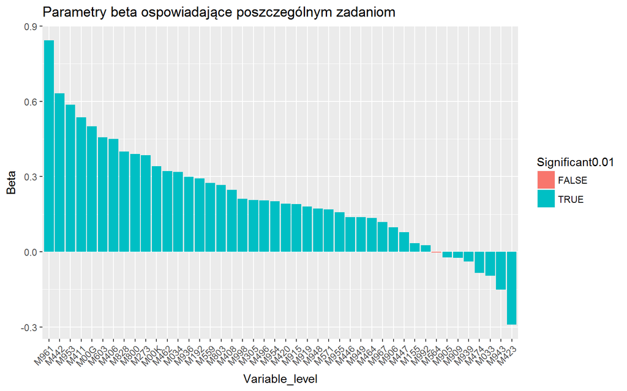

```r
coefs_task$Variable_level <- gsub("task", "", coefs_task$Variable_level)
coefs_task <- within(coefs_task, Variable_level <- factor(coefs_task$Variable_level, levels = coefs_task[order(coefs_task$Beta, decreasing = TRUE), "Variable_level"]))
ggplot(coefs_task, aes(y = Beta, x = Variable_level, fill = Significant0.01)) + geom_bar(stat = "identity") + theme(axis.text.x = element_text(angle = 45, hjust = 1)) + ggtitle("Parametry beta ospowiadające poszczególnym zadaniom")
```

Poniższy wykres jest analogiczny do poprzedniego, przy czym dotyczy interakcji zagnieżdżonej zmiennej `Q.nb` w zmiennej `task`. Dla każdej pary zadania i podpunktu kategorią referencyjną jest podpunkt pierwszy tego zadania. Na wykresie widać, że wszystkie oszacowania oprócz dwóch są istotne, a zależności między czasami rozwiązywania podpunktów są różne – w niektórych zadaniach podpunkt drugi, trzeci lu czwarty jest rozwiązywany średnio krócej, a w niektórych dłużej niż podpunkt pierwszy.

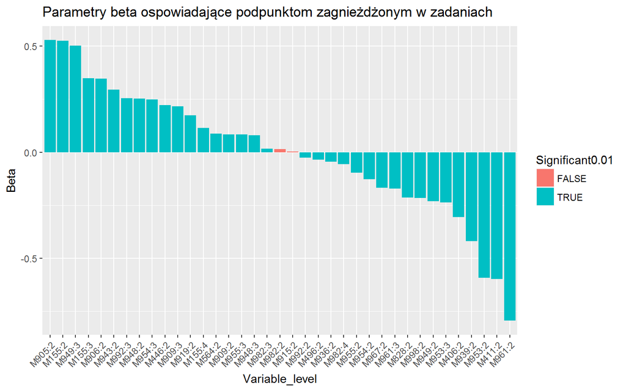

```r
coefs_taskQ.nb$Variable_level <- gsub("task", "", coefs_taskQ.nb$Variable_level)
coefs_taskQ.nb$Variable_level <- gsub("Q.nb", "", coefs_taskQ.nb$Variable_level)
coefs_taskQ.nb <- within(coefs_taskQ.nb, Variable_level <- factor(coefs_taskQ.nb$Variable_level, levels = coefs_taskQ.nb[order(coefs_taskQ.nb$Beta, decreasing = TRUE), "Variable_level"]))
ggplot(coefs_taskQ.nb, aes(y = Beta, x = Variable_level, fill = Significant0.01)) + geom_bar(stat = "identity") + theme(axis.text.x = element_text(angle = 45, hjust = 1)) + ggtitle("Parametry beta ospowiadające podpunktom zagnieżdżonym w zadaniach")
```

Poniższy wykres dotyczy parametrów dla pozycji w kwestionariuszu, przy czym kategorią referencyjną jest tu pozycja pierwsza. Wszystkie parametry są ujemne i istotne, co oznacza, że najwyższy średni czas rozwiązywania został zaobserwowany gdy zadanie było na pierwszej pozycji w kwestionariuszu. Można to interpretować tak, że uczniowie wdrażali się w rozwiązywanie zadań w miarę ich rozwiązywania.

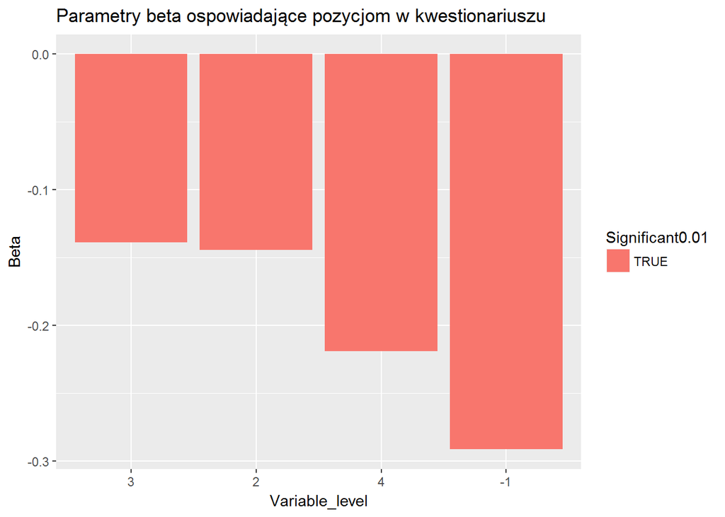

```r
coefs_position$Variable_level <- gsub("position", "", coefs_position$Variable_level)
coefs_position <- within(coefs_position, Variable_level <- factor(coefs_position$Variable_level, levels = coefs_position[order(coefs_position$Beta, decreasing = TRUE), "Variable_level"]))
ggplot(coefs_position, aes(y = Beta, x = Variable_level, fill = Significant0.01)) + geom_bar(stat = "identity") + ggtitle("Parametry beta ospowiadające pozycjom w kwestionariuszu")
```

# Diagnostyka reszt

Za pomocą szeregu wykresów i testów bazujących na resztach modelu sprawdzimy, czy spełnione są podstawowe założenia modelu regresji liniowej.

## Liniowość zależności

Poniżej przedstawiamy wykres z wartościami dopasowanymi na osi X i resztami na osi Y:

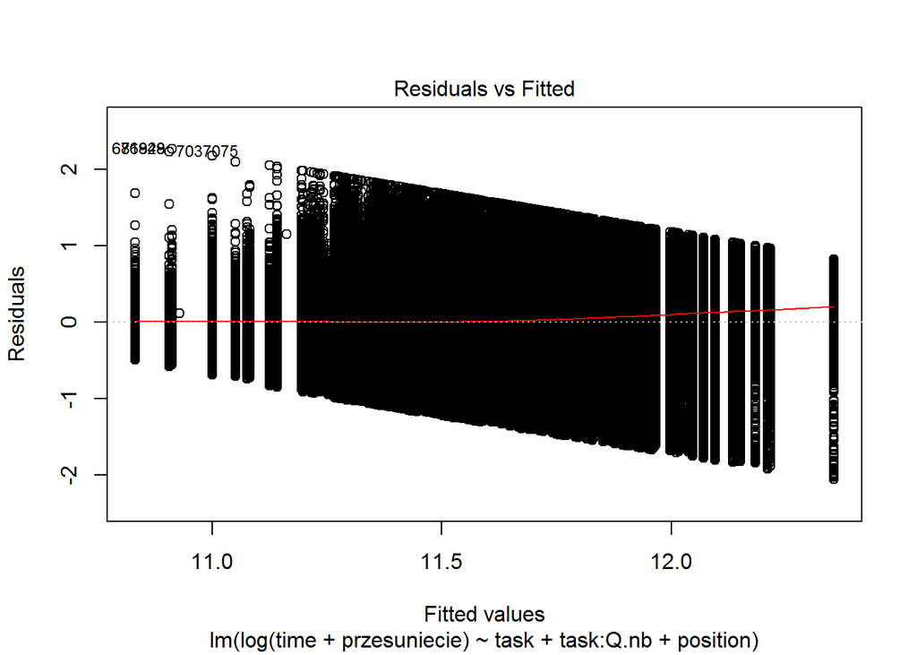

```r
plot(modelTaskQPosition, which = 1)
```

Jak widać rozproszenie punktów jest dość równomierne w poziomie (odstępy między podłużnymi grupami obserwacji wynikają z uwzględnienia w modelu jedynie jakościowych zmiennych objaśniających), a czerwona linia jest niemalże prosta, co świadczy o liniowości badanej zależności – w przeciwnym razie zależność na wykresie wyglądałaby na nieliniową. Warto zaznaczyć, że “przycięcie” wykresu jakby równoległymi prostymi może być konsekwencją przycięcia naszej zmiennej objaśnianej do sensownych czasów.

## Obserwacje wpływowe

Teraz zidentyfikujemy obserwacje wpływowe – warto zaznaczyć, że obserwacje wpływowe nie są tym samym, co odstające (pierwsze wpływają na wyniki estymacji, a drugie są nietypowe) i pierwsze z nich stanowią potencjalnie większy problem, gdyż zmieniają wyniki analizy.

### Odległość Cooka

Na poniższym wykresie przedstawiamy odległość Cooka, podstawową miarę wpływowości obserwacji:

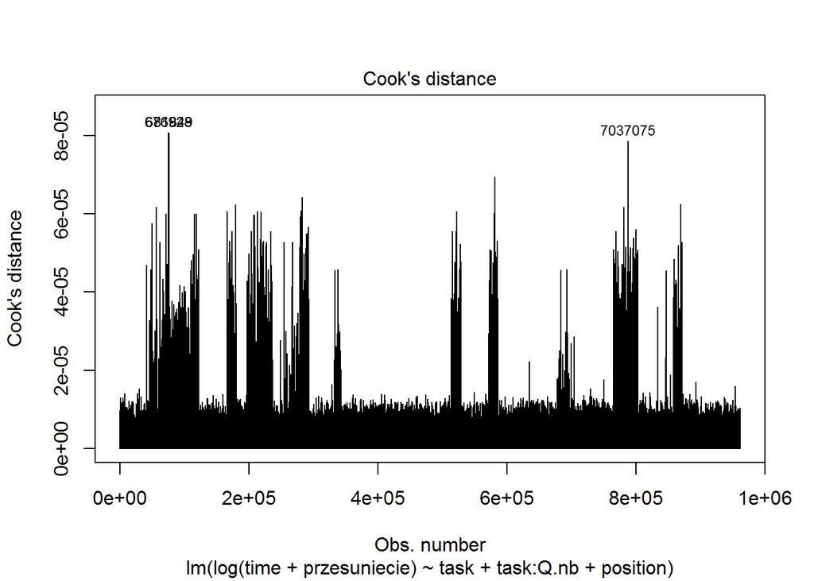

```r
plot(modelTaskQPosition, which = 4)
```

Na podstawie wykresu możemy stwierdzić, że żadna z obserwacji nie wyróżnia się specjalnie spośród pozostałych pod względem odległości Cooka. Ponadto, wyraźnie widać, że obserwacje dzielą się na dwie grupy pod względem rzędu wielkości odległości Cooka (choć różnica między tymi dwoma grupami nie jest bardzo duża).

Warto zaznaczyć, że zwykle przyjmuje się 0.5 jako próg odcięcia odległości Cooka i usuwa się obserwacje, dla których ta odległość jest wyższa od progu. W naszym przypadku nie jest to spełnione dla żadnej obserwacji, ponieważ przy tak dużym zbiorze danych jedna obserwacja ma zawsze stosunkowo niewielki wpływ na wyniki estymacji. Z tego względu nie usuwamy wyróżnionych na wykresie obserwacji ze zbioru.

### Reszty a dźwignia

Żeby potwierdzić wnioski wyciągnięte z wykresu odległości Cooka przyjrzymy się wykresowi reszt i dźwigni, która mierzy nietypowość wartości zmiennych objaśniających:

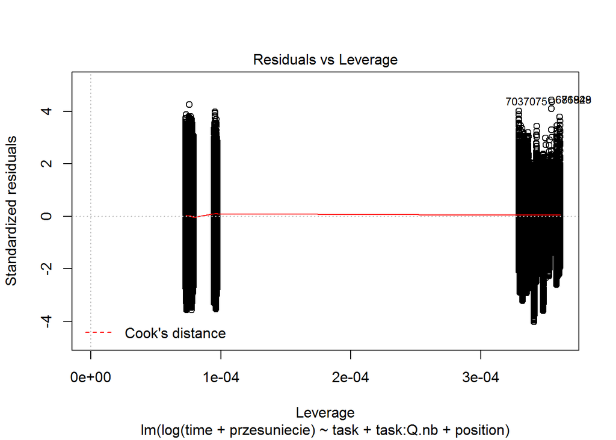

```r
plot(modelTaskQPosition, which = 5)
```

Na tym wykresie wyraźnie widać podział obserwacji na dwie grupy – o niskiej i wysokiej (względnie, ogólnie to są małe wartości) dźwigni. Wygląda jednak na to, że nie obserwujemy zależności między resztami i dźwignią gdyż dla każdej obserwowanej wartości dźwigni obserwujemy prawie pełen zakres zmienności reszt.

## Rozkład reszt modelu

Teraz przeanalizujemy reszty naszego modelu. W tym celu wyznaczymy reszty standardowe i studentyzowane (przy tak dużej próbie jak nasza różnica pomiędzy nimi będzie niezauważalna):

```r
reszty <- rbind(data.frame(reszty = rstandard(modelTaskQPosition), typ = "Reszty standardowe"), data.frame(reszty = rstudent(modelTaskQPosition), typ = "Reszty studentyzowane"))
```

### Jednorodność wariancji

Kluczowym założeniem modelu regresji jest jednorodność wariancji reszt. Poniższy wykres pomaga zilustrować sensowność tego założenia dla naszego modelu:

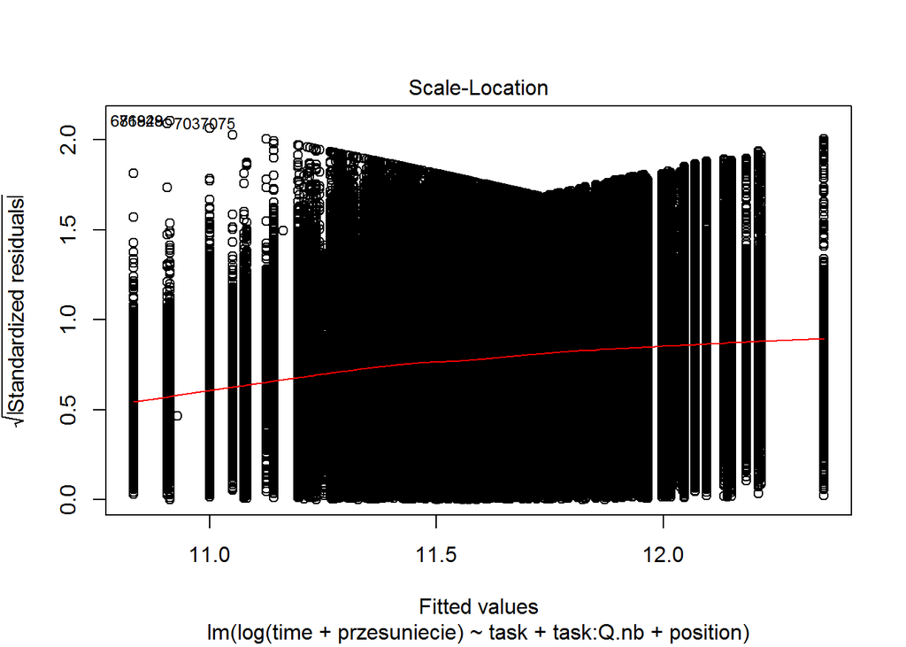

```r
plot(modelTaskQPosition, which = 3)
```

Na wykresie widać, że rozproszenie reszt rośnie wraz ze wzrostem wartości dopasowanych, co może oznaczać sprzeczność z założeniem jednorodności wariancji, dla potwierdzenia tego przeprowadzamy test Goldfeldaa-Quandta:

```r
gqtest(modelTaskQPosition, order.by = ~Q.nb, data = sample_data)
```

```
##
##  Goldfeld-Quandt test
##
## data:  modelTaskQPosition
## GQ = 1.0635, df1 = 480670, df2 = 480670, p-value < 2.2e-16
## alternative hypothesis: variance increases from segment 1 to 2
```

Przy każdym sensownym poziomie istotności odrzucamy hipotezę zerową o równości wariancji przy podziale próby na dwie części (po uszeregowaniu według zmiennej `Q.nb`). Sugeruje to pominięcie istotnych zmiennych objaśniających (na dalszym etapie analizy dodamy kolejne). Gdyby był to nasz ostateczny model, to moglibyśmy również zastosować odpowiednią poprawkę błędów standardowych.

### Normalność rozkładu

Kolejnym założeniem modelu jest normalność rozkładu reszt. Na poniższym wykresie przedstawiamy ten rozkład dla obu rodzajów reszt wraz z gęstością rozkładu normalnego o parametrach odpowiadających statystykom z próby.

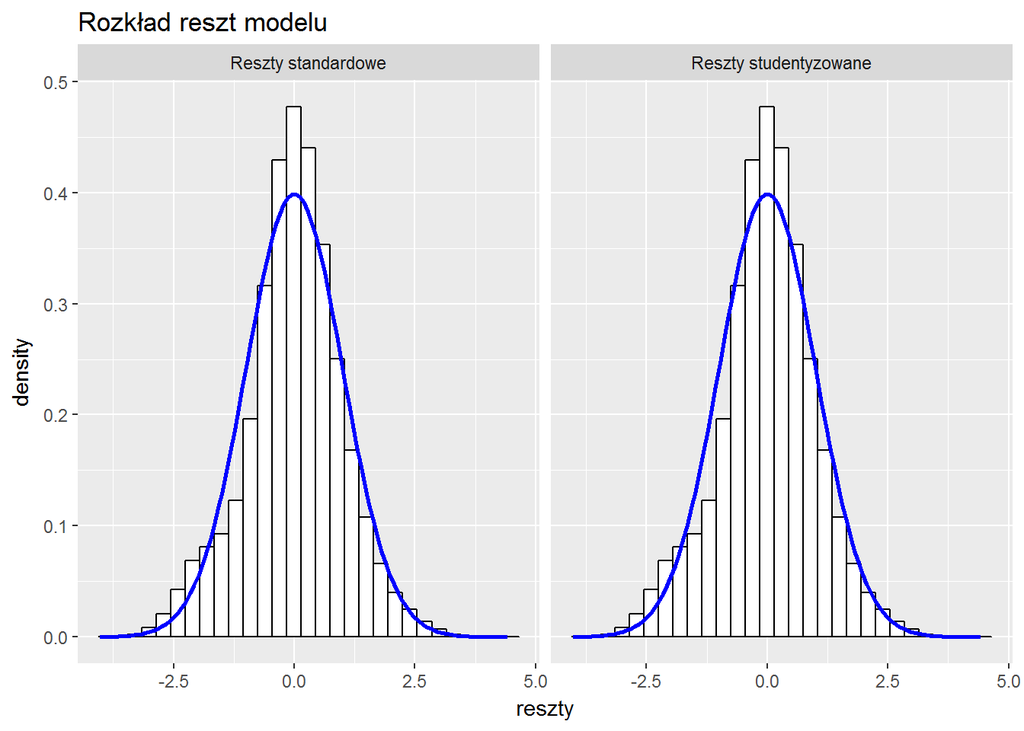

```r
ggplot(reszty, aes(x = reszty)) + geom_histogram(aes(y=..density..), binwidth = 0.3, color = "black", fill = "white") + stat_function(fun = dnorm, args=list(mean = mean(reszty$reszty), sd = sd(reszty$reszty)), color = "blue", size = 1) + ggtitle("Rozkład reszt modelu") + facet_grid(. ~ typ)
```

Na obu wykresach widać, że rozkład naszych reszt jest trochę bardziej spiczasty od rozkładu normalnego. Faktycznie, kurtoza rozkładów reszt wynosi 3.5103996 oraz 3.5104139, odpowiednio. Jest to niewiele więcej niż wartość 3 dla rozkładu normalnego, jednak przy takiej dużej próbie taka spiczastość z pewnością spowoduje odrzucenie hipotezy o normalności rozkładu w teście statystycznym.

Rozbieżność rozkładu reszt od rozkładu normalnego potwierdza również następujący QQ-plot dla reszt studentyzowanych:

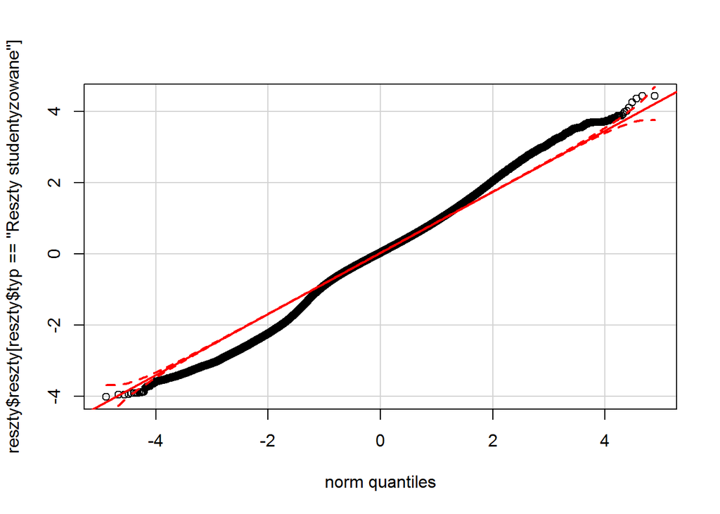

```r
qqPlot(reszty$reszty[reszty$typ == "Reszty studentyzowane"])
```

Ostatecznie potwierdzamy to testem:

```r
ad.test(reszty$reszty[reszty$typ == "Reszty standardowe"])
```

```
##
##  Anderson-Darling normality test
##
## data:  reszty$reszty[reszty$typ == "Reszty standardowe"]
## A = 3003.2, p-value < 2.2e-16
```

```r
ad.test(reszty$reszty[reszty$typ == "Reszty studentyzowane"])
```

```
##
##  Anderson-Darling normality test
##
## data:  reszty$reszty[reszty$typ == "Reszty studentyzowane"]
## A = 3003.3, p-value < 2.2e-16
```

Nasze reszty bez wątpienia nie mają rozkładu normalnego, jednak na podstawie histogramów stwierdzamy, że rozbieżność nie jest na tyle duża, żeby zdyskwalifikować zbudowany model, ale warto nad nim dalej popracować, co niniejszym czynimy.

# Wnioski

Przedstawiony model stanowi pierwsze podejście do zrozumienia czynników kształtujących czas rozwiązywania zadania. Ze względu na silnie skośny rozkład zmiennej objaśnianej zastosowaliśmy optymalną (spośród rozważanych) transformację logarytmiczną z przeunięciem. Niestety mimo tej transformacji przeprowadzone testy statystyczne wskazują na niejednorodność wariancji reszt i niezgodność ich rozkładu z rozkładem normalnym. Model ten wymaga zatem rozbudowania, przede wszystkim należy rozpatrzyć włączenie kolejnych zmiennych objaśniających.